# Exp 1

```
individual subject analysis -- all converged
Following are histograms of each subject's data for neighboring quadrants, fit to above swap model
```

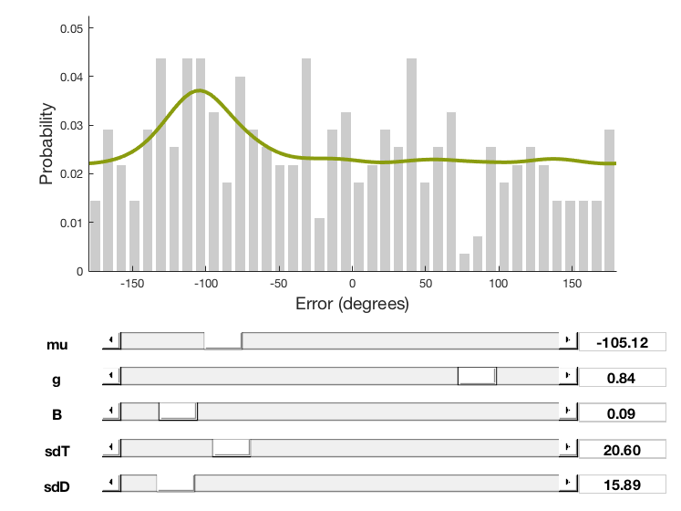

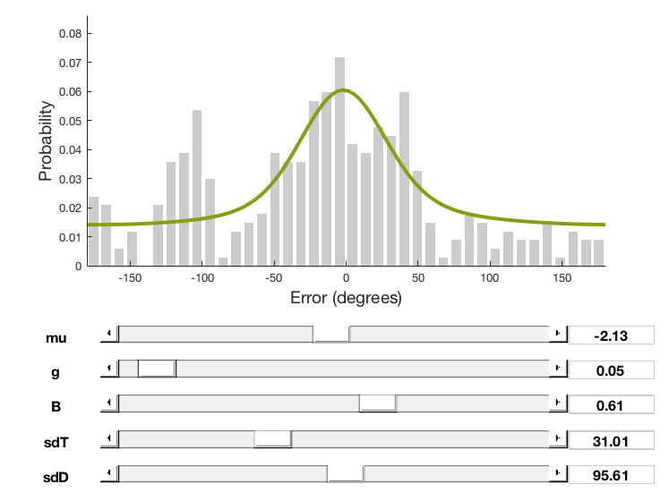

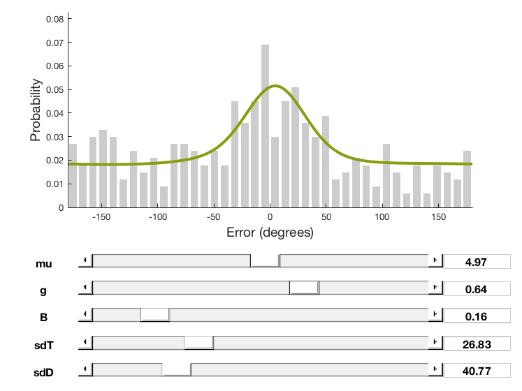

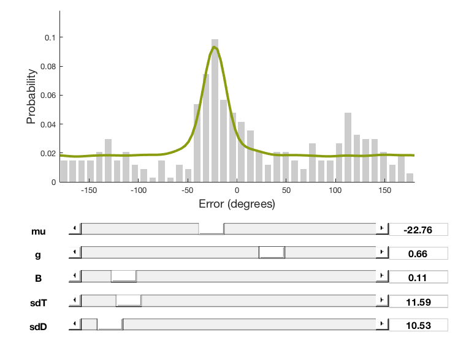

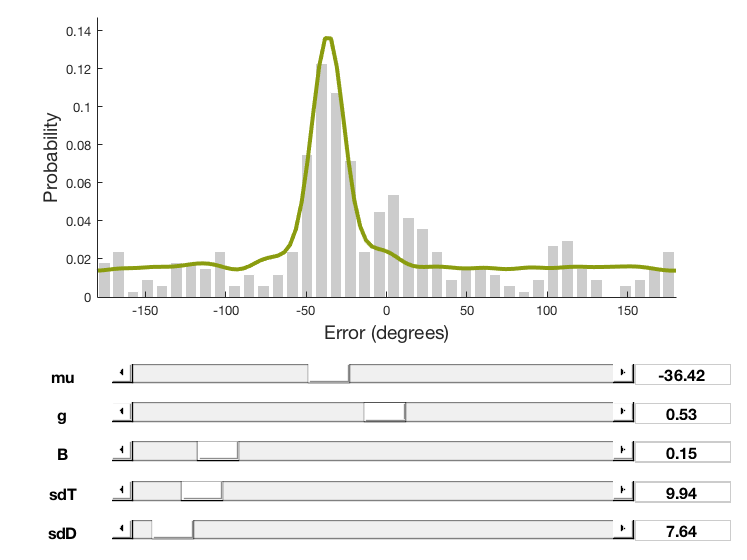

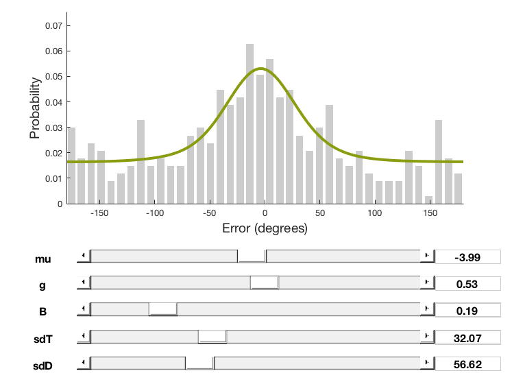

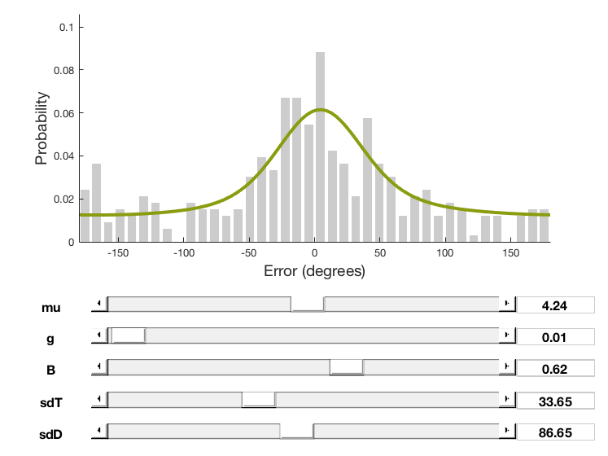

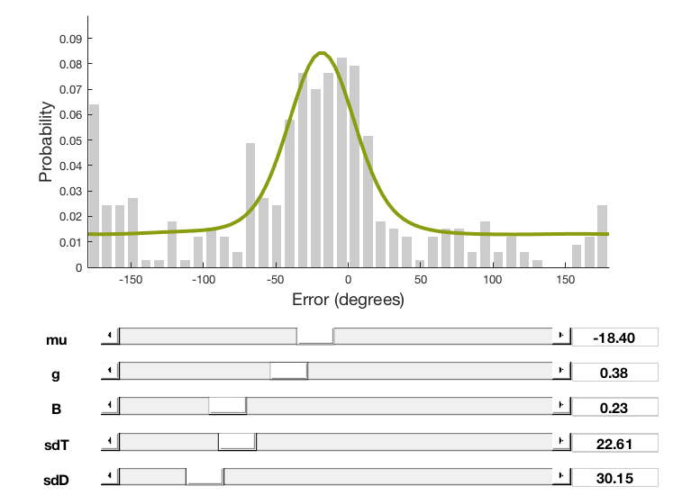

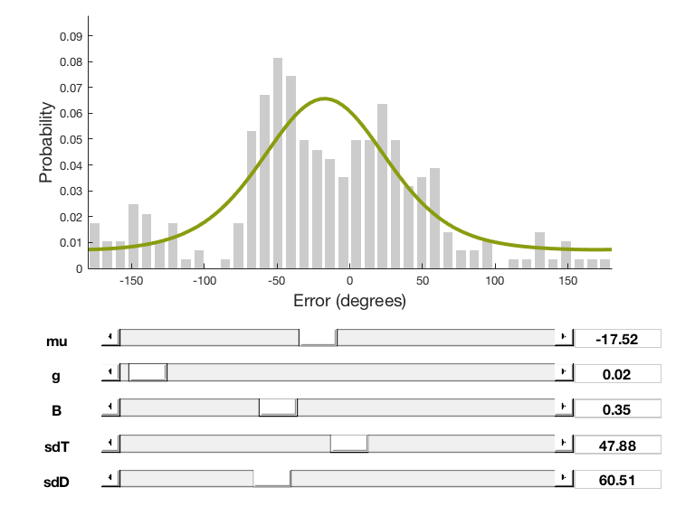

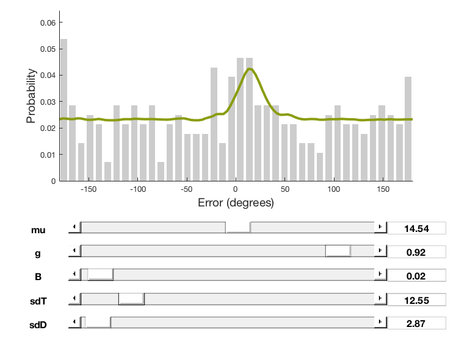

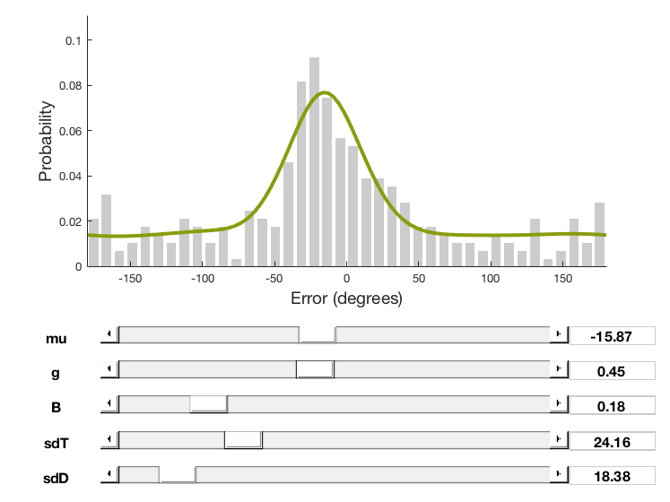

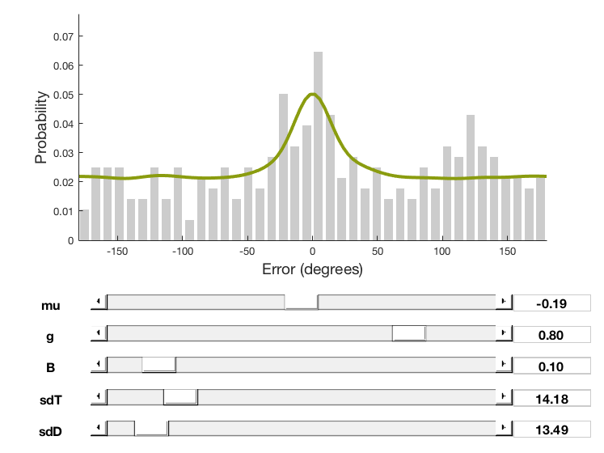

[4 more figures not shown]

```matlab
disp('individual subject analysis -- all converged')
disp('Following are histograms of each subject''s data for neighboring quadrants, fit to above swap model');
cd '/Users/scotti.5/Dropbox/Shared Lab Folder/Experiments/Contextual_LTM/Contextual bias in LTM Exp_V3/analysis'
openfig('allquads_swap_subject1.fig');
openfig('allquads_swap_subject2.fig');
openfig('allquads_swap_subject3.fig');
openfig('allquads_swap_subject4.fig');
openfig('allquads_swap_subject5.fig');
openfig('allquads_swap_subject6.fig');
openfig('allquads_swap_subject7.fig');
openfig('allquads_swap_subject8.fig');
openfig('allquads_swap_subject9.fig');
openfig('allquads_swap_subject10.fig');
openfig('allquads_swap_subject11.fig');
openfig('allquads_swap_subject12.fig');
openfig('allquads_swap_subject13.fig');
openfig('allquads_swap_subject14.fig');
openfig('allquads_swap_subject15.fig');
openfig('allquads_swap_subject16.fig');
```

- Mean shift: -15.9 (although this doesn't really tell us anything because all quadrants were used, not just the neighboring quadrants which could be collapsed to reflect negative distractor bias)
- Mean guessing distribution across individuals: 46.1%
- Mean biased distribution across individuals: 25.6%
- This means target distribution was the remainder, or approximately 28.3% of responses
- Mean stdev of target distribution across individuals: 24.1
- Mean stdev of biased distribution across individuals: 42.8

# Exp 2

## Design

- 20 participants were again collected (nobody was excluded due to repeat detection task)
- 324 objects presented, this time using objects with modified color so all objects truly were sampled from the same isoluminant color wheel:
- Posterized stimuli (basically divide image into only 3 colors):

[figure not shown]

- Did record the study trial for object presentation to be compared with individual test trial, and did do explicit continuous color report (but not implicit color report) as well as the post-survey.

## Non-modelling Behavioral Results

| all quads |  |  |  |  |  |  |  |  |  |  |  |  |  |  |  |  |  |  |  |  |  |
| --- | --- | --- | --- | --- | --- | --- | --- | --- | --- | --- | --- | --- | --- | --- | --- | --- | --- | --- | --- | --- | --- |
| closer |  |  |  |  |  |  |  |  |  |  |  |  |  |  |  |  |  |  |  | Means | P-value |
| 149 | 150 | 151 | 171 | 178 | 194 | 156 | 167 | 143 | 203 | 160 | 172 | 149 | 164 | 165 | 147 | 163 | 197 | 158 | 159 | 164.8 |  |
| farther |  |  |  |  |  |  |  |  |  |  |  |  |  |  |  |  |  |  |  |  | 0.264975249 |
| 174 | 174 | 165 | 150 | 142 | 130 | 160 | 152 | 180 | 120 | 163 | 149 | 174 | 159 | 158 | 172 | 160 | 125 | 162 | 163 | 156.6 |  |

| neigh quads |  |  |  |  |  |  |  |  |  |  |  |  |  |  |  |  |  |  |  |  |  |
| --- | --- | --- | --- | --- | --- | --- | --- | --- | --- | --- | --- | --- | --- | --- | --- | --- | --- | --- | --- | --- | --- |
| closer |  |  |  |  |  |  |  |  |  |  |  |  |  |  |  |  |  |  |  |  |  |
| 52 | 52 | 51 | 56 | 60 | 70 | 43 | 50 | 43 | 64 | 53 | 56 | 50 | 51 | 45 | 53 | 49 | 63 | 55 | 54 | 53.5 |  |
| farther |  |  |  |  |  |  |  |  |  |  |  |  |  |  |  |  |  |  |  |  | 0.892733812 |
| 56 | 56 | 55 | 51 | 46 | 38 | 65 | 57 | 65 | 43 | 55 | 52 | 57 | 57 | 63 | 55 | 58 | 45 | 51 | 53 | 53.9 |  |

| rich quad |  |  |  |  |  |  |  |  |  |  |  |  |  |  |  |  |  |  |  |  |  |
| --- | --- | --- | --- | --- | --- | --- | --- | --- | --- | --- | --- | --- | --- | --- | --- | --- | --- | --- | --- | --- | --- |
| closer |  |  |  |  |  |  |  |  |  |  |  |  |  |  |  |  |  |  |  |  |  |
| 67 | 73 | 75 | 89 | 91 | 100 | 81 | 84 | 78 | 112 | 79 | 87 | 71 | 88 | 90 | 71 | 84 | 103 | 80 | 78 | 84.05 |  |
| farther |  |  |  |  |  |  |  |  |  |  |  |  |  |  |  |  |  |  |  |  | 0.116778351 |
| 94 | 89 | 81 | 73 | 69 | 62 | 74 | 74 | 83 | 50 | 83 | 72 | 91 | 73 | 71 | 86 | 78 | 57 | 80 | 84 | 76.2 |  |

# Exp 2 Modelling

### Neighboring Quadrants (collapsed), Standard Mixture Model (with bias)

```
subjects collapsed
```

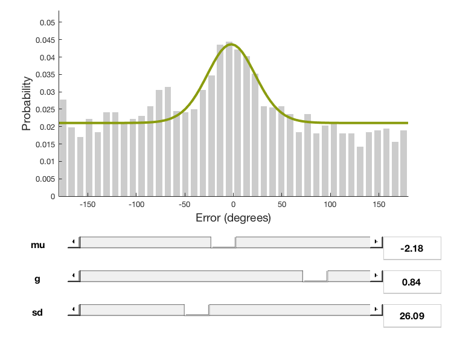

```matlab
disp('subjects collapsed');
cd '/Users/scotti.5/Dropbox/Shared Lab Folder/Experiments/Contextual_LTM/Contextual bias in LTM Exp_V8/analysis'
openfig('neigh_coll_SMM.fig');
```

```
indiv. subjects-- subj4, subj6, subj12, sub18 did not converge
```

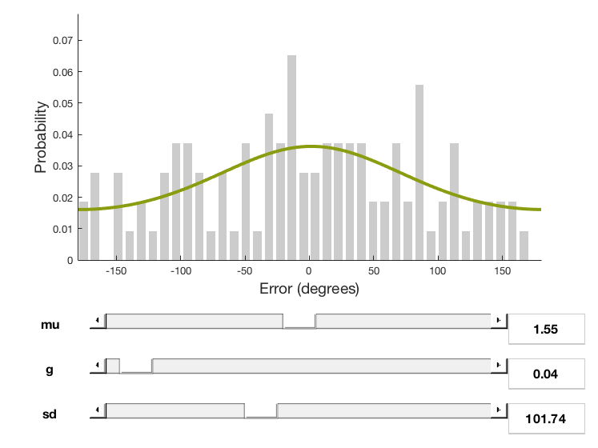

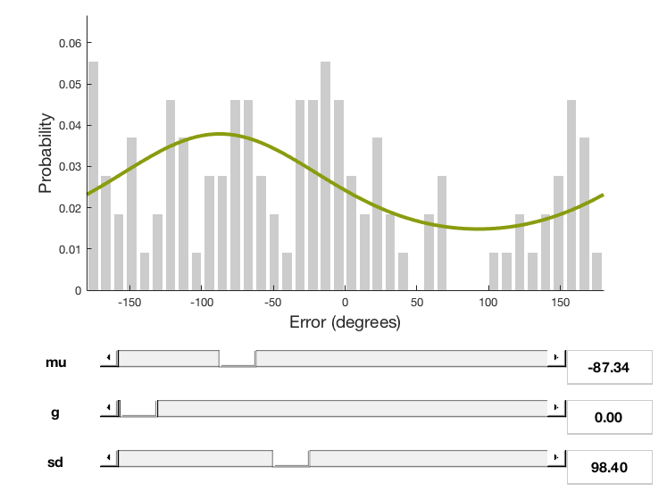

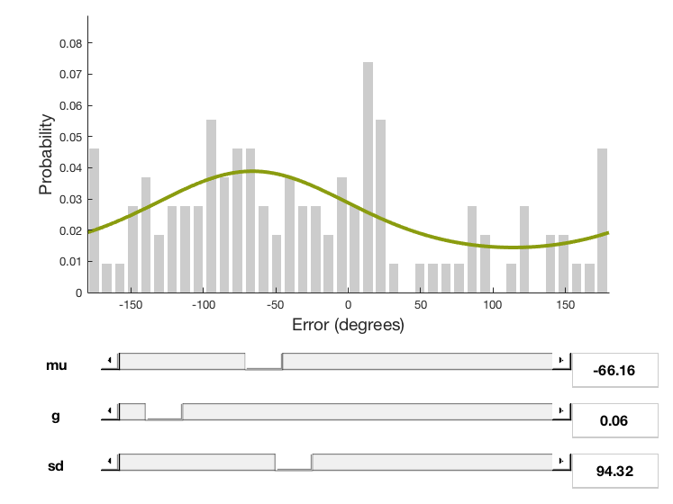

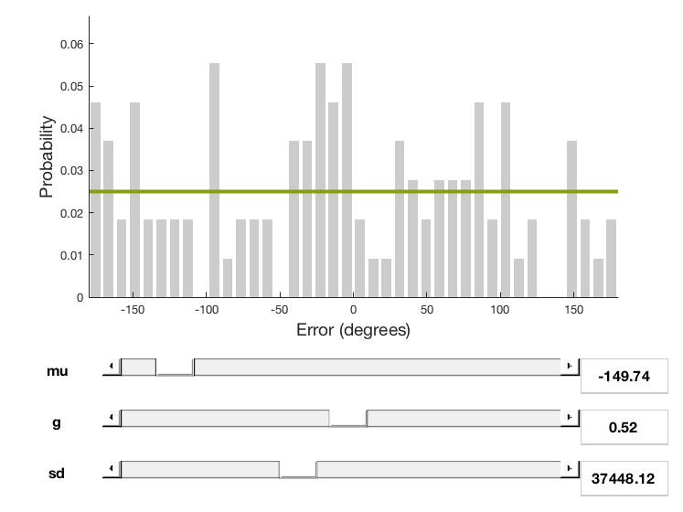

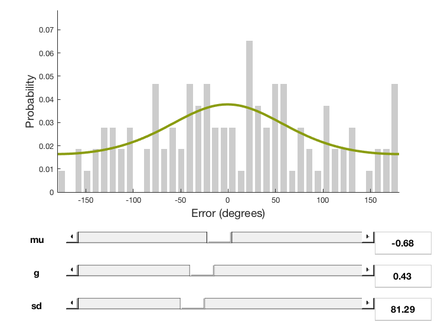

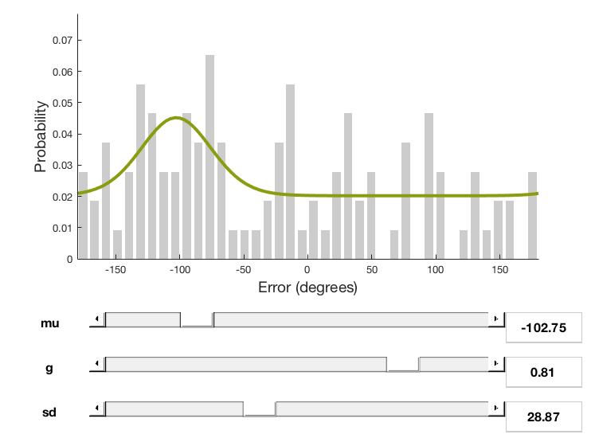

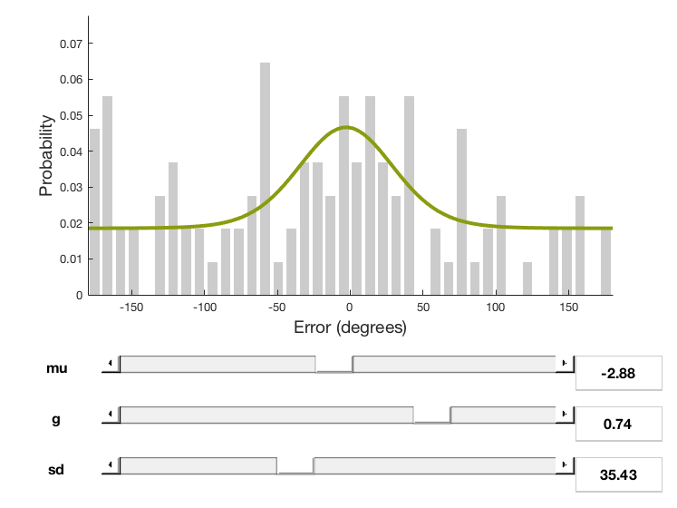

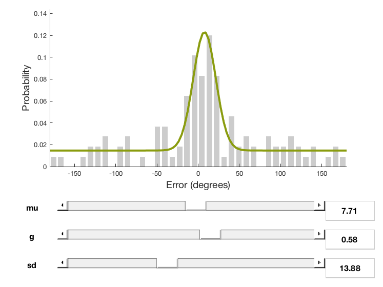

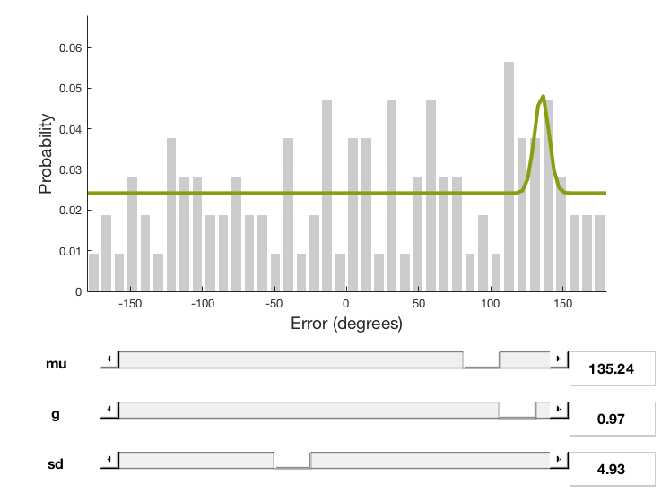

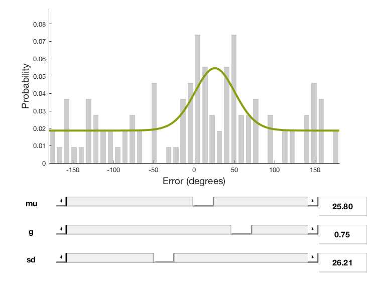

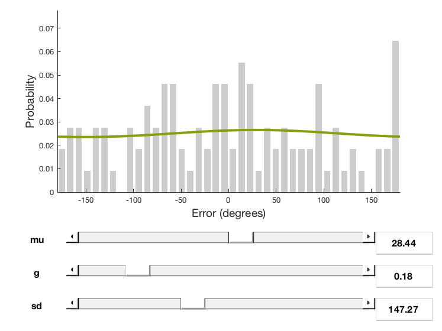

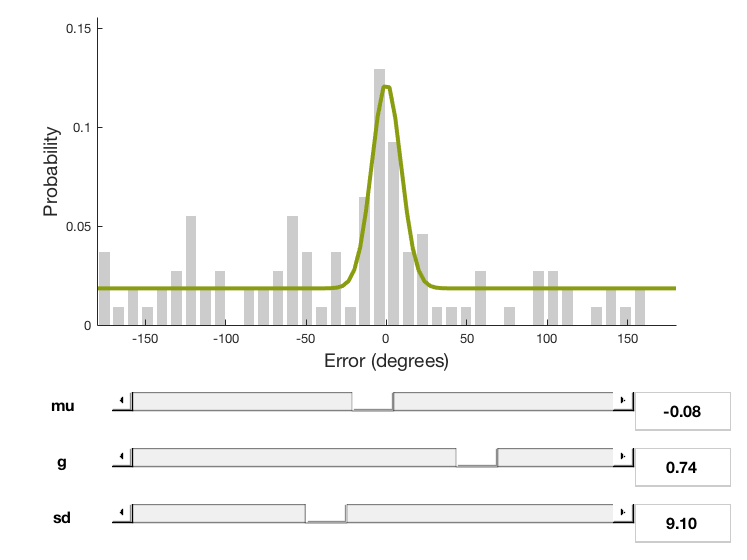

[4 more figures not shown]

```matlab
disp('indiv. subjects-- subj4, subj6, subj12, sub18 did not converge');
cd '/Users/scotti.5/Dropbox/Shared Lab Folder/Experiments/Contextual_LTM/Contextual bias in LTM Exp_V8/analysis'
openfig('subject1.fig');
openfig('subject2.fig');
openfig('subject3.fig');

openfig('subject5.fig');

openfig('subject7.fig');
openfig('subject8.fig');
openfig('subject9.fig');
openfig('subject10.fig');
openfig('subject11.fig');

openfig('subject13.fig');
openfig('subject14.fig');
openfig('subject15.fig');
openfig('subject16.fig');
openfig('subject17.fig');

openfig('subject19.fig');
openfig('subject20.fig');
```

### All Quadrants, Swap Model (individual distractors, flexible stdev for guessing distr.)

```
Subjects collapsed:
```

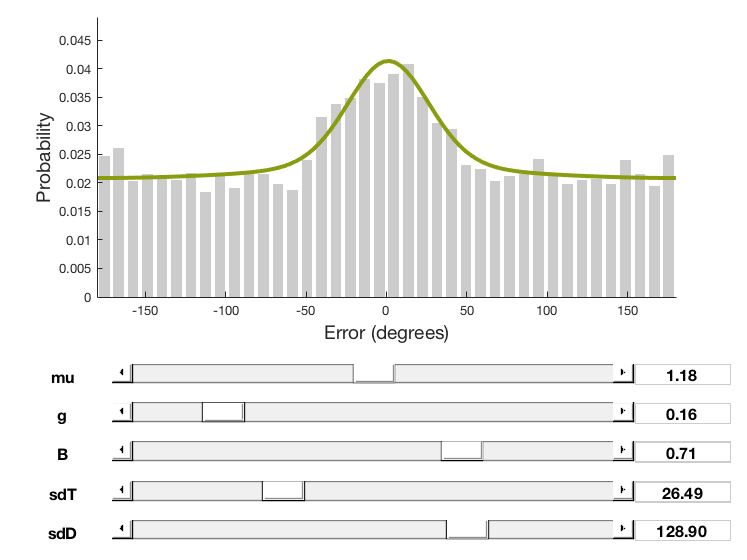

```matlab
disp('Subjects collapsed:');
cd '/Users/scotti.5/Dropbox/Shared Lab Folder/Experiments/Contextual_LTM/Contextual bias in LTM Exp_V8/analysis'
openfig('allquad_swap_collapsed.fig');
```

```
Individual subjects (only those who survived SMM convergence). Subj14 did not converge
```

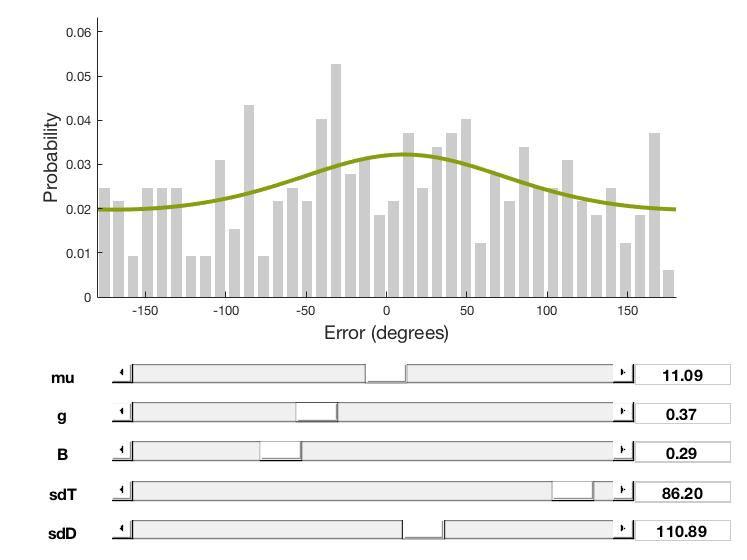

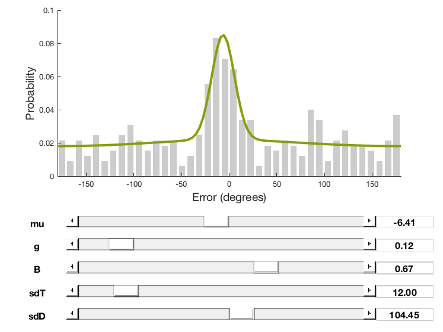

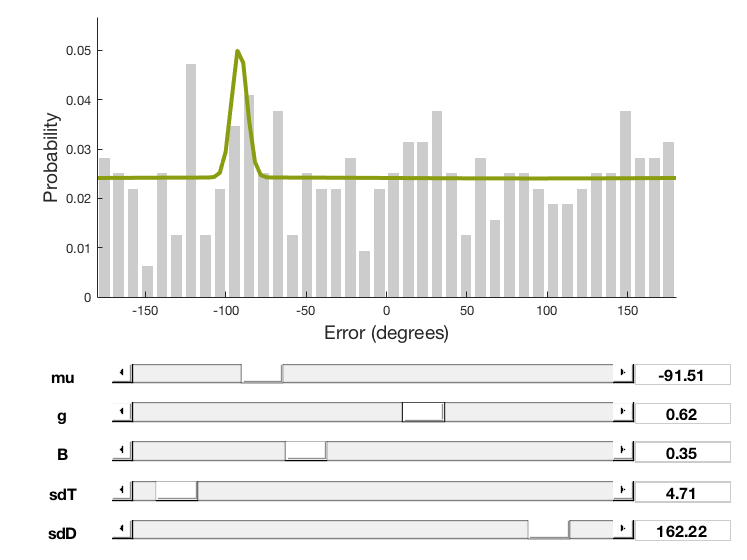

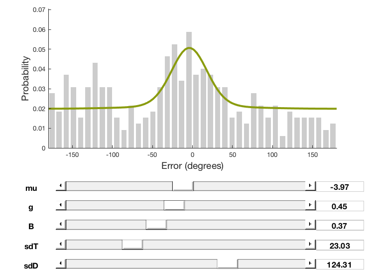

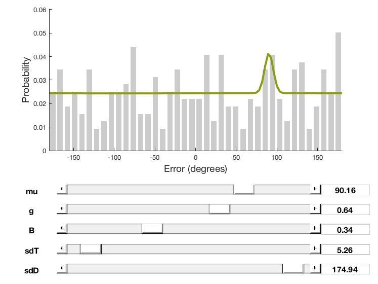

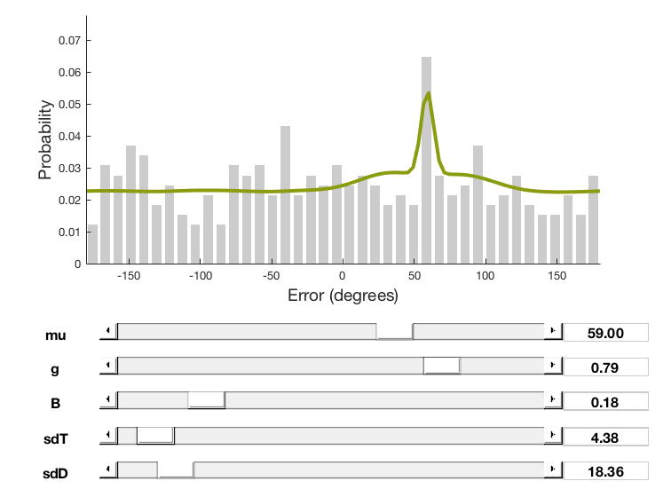

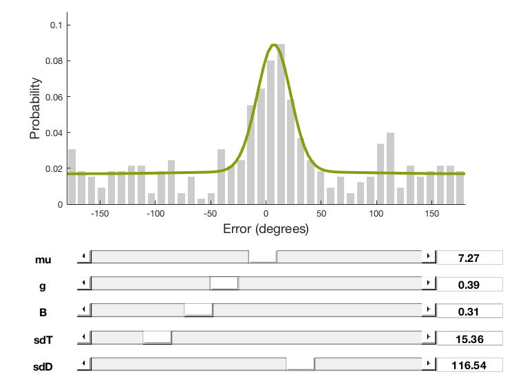

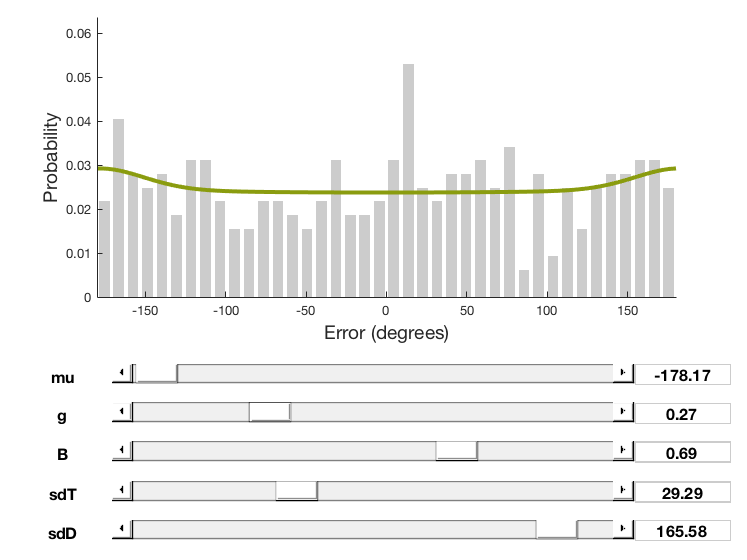

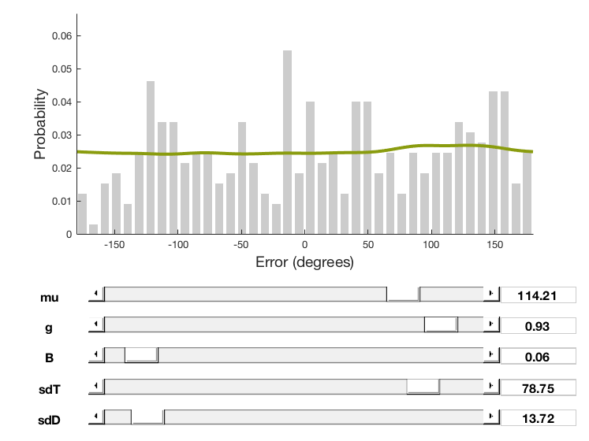

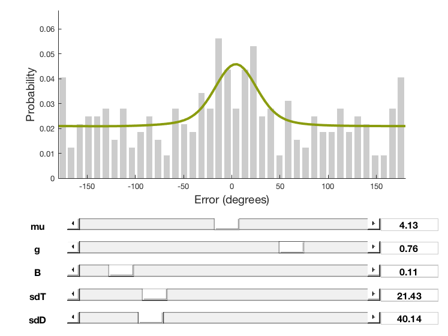

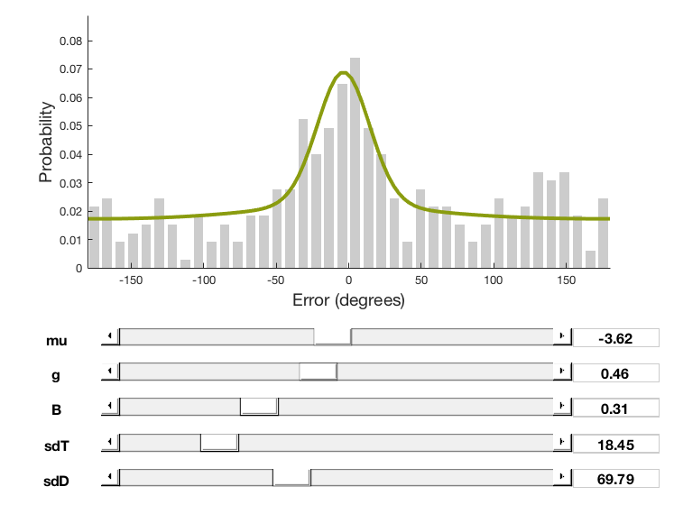

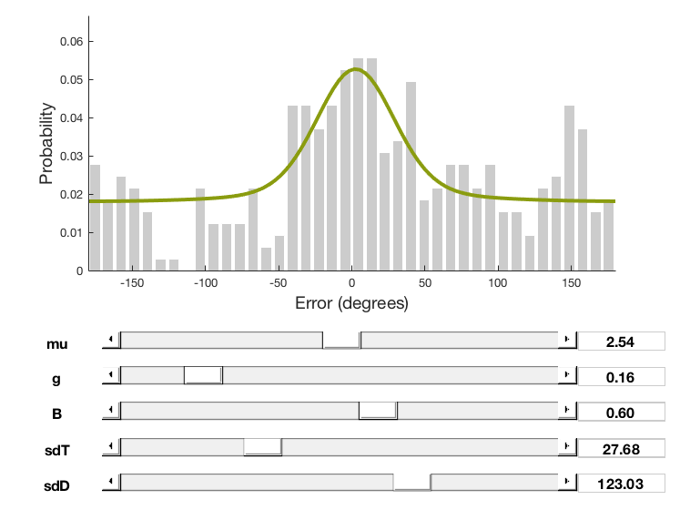

[3 more figures not shown]

```matlab
disp('Individual subjects (only those who survived SMM convergence). Subj14 did not converge');
cd '/Users/scotti.5/Dropbox/Shared Lab Folder/Experiments/Contextual_LTM/Contextual bias in LTM Exp_V8/analysis'
openfig('allquads_swap_subject1.fig');
openfig('allquads_swap_subject2.fig');
openfig('allquads_swap_subject3.fig');

openfig('allquads_swap_subject5.fig');

openfig('allquads_swap_subject7.fig');
openfig('allquads_swap_subject8.fig');
openfig('allquads_swap_subject9.fig');
openfig('allquads_swap_subject10.fig');
openfig('allquads_swap_subject11.fig');

openfig('allquads_swap_subject13.fig');

openfig('allquads_swap_subject15.fig');
openfig('allquads_swap_subject16.fig');
openfig('allquads_swap_subject17.fig');

openfig('allquads_swap_subject19.fig');
openfig('allquads_swap_subject20.fig');
```

*It seems like a number of individual fits don't make sense... I'm looking at some graphs and thinking the std for the biased distribution here is way too high, or the biased mean was placed completely off the mark.*

- Mean shift: 0.29
- Mean guessing distribution across individuals: 53.1%
- Mean biased distribution across individuals: 30.8%
- This means target distribution was the remainder, or approximately 16.1% of responses
- Mean stdev of target distribution across individuals: 25.7
- Mean stdev of biased distribution across individuals: 85.5

## Comments, Future Directions

First, we need to figure out some exclusion criteria. I initially thought it could be something simple like, exclude if a subject doesn't fit a standard mixture model (all quadrants), but apparently even extremely messy data can still converge on these models. So perhaps exclude based on some other additional criteria?

The data for Expt. 2 looks much more messy than Expt 1. This may be because of the objects looking somewhat degraded due to the posterization, or the fact that all objects now share the exact same color wheel makes remembering more difficult. I may need to reduce the number of objects from 300-something to 200-something to find more reliable behavioral performance using posterized objects. However, this may lead to tradeoff where less trials makes modelling individuals more difficult. Else, I may want to replicate Expt. 1 simply to correct for the problems I outlined above (aside from the posterization).

I also now coded up a confidence report that may be used (specifying a range of values the subject believes the correct color may lie). This may be helpful in figuring out how bias relates to confidence in responses.

Unfortunately, slots for this week are not getting filled up (likely because midterms and it being the Spring?). I do have, however, have an mTurk version of the experiment nearly all ready to go if we want to collect data more quickly (you can see what it currently looks like here: https://paulscotti.github.io/mturk/Cont_LTM_101_3).

There are still modelling ideas I have yet to realize, for instance the idea of increasing the magnitude of bias in the model as linear function of how far away the rich quadrant was from that object's original color.